# Final Work

Abena Mantebea

11/5/2021

## Introduction

This is a second trial run toward becoming skilled in using R. My colleagues and I tried to recollect what had been taught during our last session. We had some difficulties but we managed to sail through them to the best of our abilities. We created a new R markdown and followed the steps we remembered. Emil and Grace exaggerated in their comments for their introduction about me being their team leader. Kindly ignore that my honourable RD Eric. Emil and Grace took over at this point and took me through what they did in the R markdown. This was done smoothly. However theirs was different from what I was taught because I was taught in advance. It was fun though going through everything. We are now going to start the actual lesson for today(at 5:49pm). We however couldn’t finish going through the task given. We went our separate ways with the promise of finishing up. Today is November 5th and I’m continuing the work. I however made a mistake of working in the R Script intsead of the markdown. So I’m about to redo everything in the markdown and submit the final work to our very own RD Eric Komla Anku. Today is 25th November and I’m continuing the assignment given on making our own plots with ggplot2.

```r
#load/install packages
pacman::p_load(tidyverse,here,rio,skimr,GGally,gtsummary,finalfit)
```

```r
here()
```

```
## [1] "C:/Users/hp/Documents/Third chance/third-chance"
```

```r
import(here("data", "cancer_data.csv"))
```

```
##    patient_id age gender      bmi smoking exercise fruit veg cancer
## 1           1  61      0 20.79721       2        0     1   2      0
## 2           2  68      1 27.30000       0        0     0   1      0
## 3           3  62      1 22.18310       0        0     1   3      0
## 4           4  61      1 35.26846       2        0     2   4      0
## 5           5  58      1 22.67334       1        0     3   1      0
## 6           6  46      1 27.69035       1        0     0   2      1
## 7           7  67      1 28.95731       2        0     0   3      1
## 8           8  68      0 19.83399       0        0     3   4      0
## 9           9  53      1 17.55142       0        0     1   3      0
## 10         10  59      0 27.72287       2        0     1   3      0
## 11         11  72      0 22.71064       1        0     1   2      0
## 12         12  45      1 40.61840       1        0     1   2      0
## 13         13  58      0 20.51381       2        0     0   3      0
## 14         14  44      1 17.62536       0        0     2   4      0
```

[output cut: 52 more lines]

```r
mantebea <- import(here("data", "cancer_data.csv"))
```

```r
mantebea <- mantebea %>%
                  mutate(
                         gender = factor (gender) %>%
                                 fct_recode ("Male" = "0",
                                             "Female" = "1") %>%
                                 ff_label ("Gender") %>%
                         fct_relevel ("Male", "Female"),

                         smoking = factor (smoking) %>%
                                  fct_recode ("Never smoked" = "0",
                                              "Light smoker" = "1",
                                              "Heavy smoker" = "2") %>%
                                  ff_label ("Smoking") %>%
                         fct_relevel ("Never smoked", "Light smoker", "Heavy smoker") ,

                         exercise = factor (exercise) %>%
                                   fct_recode ("Sedentary" = "0",
                                               "Active" = "1",
                                               "Very active" = "2") %>%
                                   ff_label ("Exercise") %>%
                         fct_relevel ("Sedentary", "Active", "Very active"),

                         cancer = factor (cancer) %>%
                                 fct_recode ("Yes" = "0",
                                             "No" = "1") %>%
                                 ff_label ("Cancer") %>%
                         fct_relevel ("Yes", "No"),

                         age = age %>%
                           ff_label ("Age"),

                         patient_id = patient_id %>%
                           ff_label ("Patient ID"),

                         bmi = bmi %>%
                           ff_label ("BMI")
                  )
```

```r
bmi_cat<-
        ifelse (mantebea$bmi <18.5, "Underweight",
                ifelse (mantebea$bmi >=18.5 & mantebea$bmi <=24.9, "Normal",
                        ifelse (mantebea$bmi >=25 & mantebea$bmi <=29.9, "Overweight",
                                ifelse (mantebea$bmi >30, "Obese", NA))))
```

```r
mantebea$bmi_cat <- bmi_cat
```

```r
mantebea <- mantebea %>%
                  mutate(
                    bmi_cat = factor (bmi_cat) %>%
                             ff_label ("BMI Cat") %>%
                             fct_relevel ("Underweight", "Normal", "Overweight", "Obese")
                  )
```

```r
#create a table summary of cancer data
tbl_summary(mantebea)
```

| **Characteristic** | **N = 66**<sup>1</sup> |
| --- | --- |
| Patient ID | 34 (17, 50) |
| Age | 61 (54, 70) |
| Gender |  |
| Male | 33 (50%) |
| Female | 33 (50%) |
| BMI | 24.8 (21.4, 27.3) |
| Smoking |  |
| Never smoked | 26 (40%) |
| Light smoker | 18 (28%) |
| Heavy smoker | 21 (32%) |
| Unknown | 1 |
| Exercise |  |
| Sedentary | 22 (33%) |
| Active | 22 (33%) |
| Very active | 22 (33%) |
| fruit |  |
| 0 | 24 (36%) |
| 1 | 24 (36%) |
| 2 | 12 (18%) |
| 3 | 5 (7.6%) |
| 4 | 1 (1.5%) |
| veg |  |
| 0 | 2 (3.0%) |
| 1 | 11 (17%) |
| 2 | 15 (23%) |
| 3 | 18 (27%) |
| 4 | 12 (18%) |
| 5 | 3 (4.5%) |
| 6 | 2 (3.0%) |
| 9 | 3 (4.5%) |
| Cancer | 51 (77%) |
| BMI Cat |  |
| Underweight | 8 (12%) |
| Normal | 26 (39%) |
| Overweight | 30 (45%) |
| Obese | 2 (3.0%) |

<sup>*1*</sup> Median (IQR); n (%)

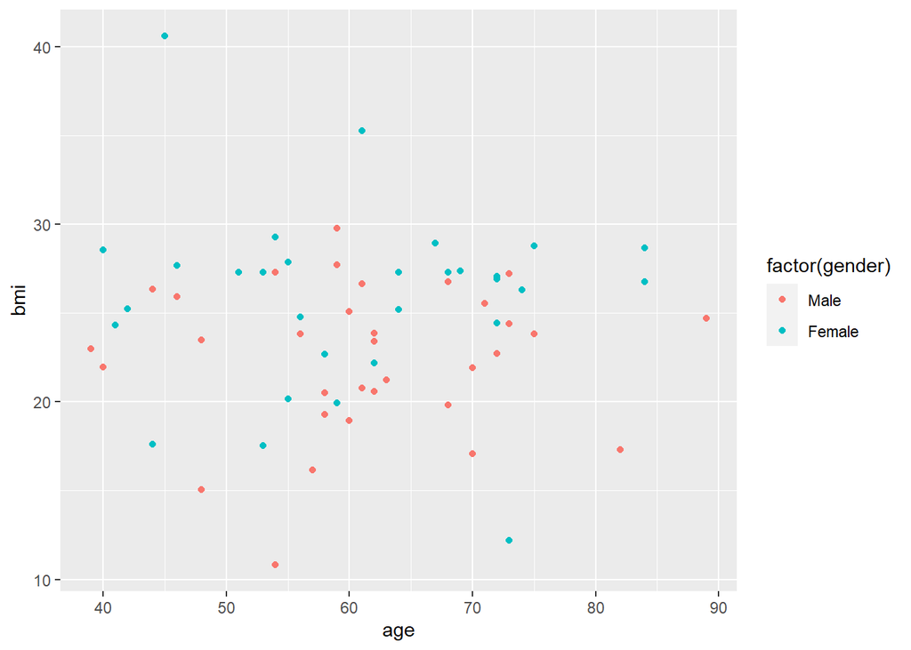

```r
#creating scatterplot
ggplot(mantebea, aes(x=age, y=bmi, color=factor(gender))) +geom_point()
```

```r
## In the chunk below, I changed the default point shape of the plot from 16 to 8.
```

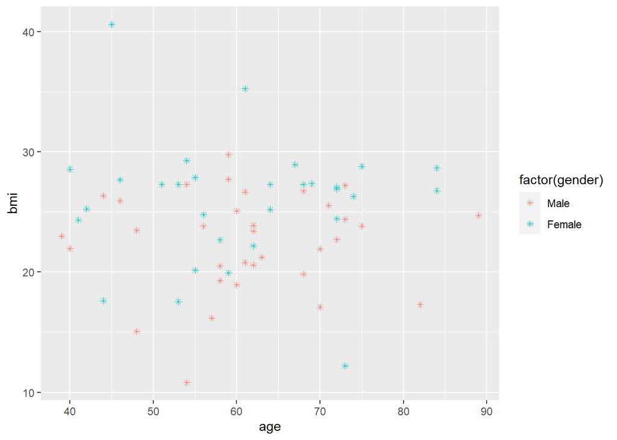

```r
ggplot(mantebea, aes(x=age, y=bmi, color=factor(gender))) +geom_point(shape = 8)
```

```r
## Faceting was introduced in this function. As such, the same plot produced in the previous function was further divided or split into subgroups based on their respective bmi categories. From observation. more females fell under the overweight section whiles more males were classified as normal.
```

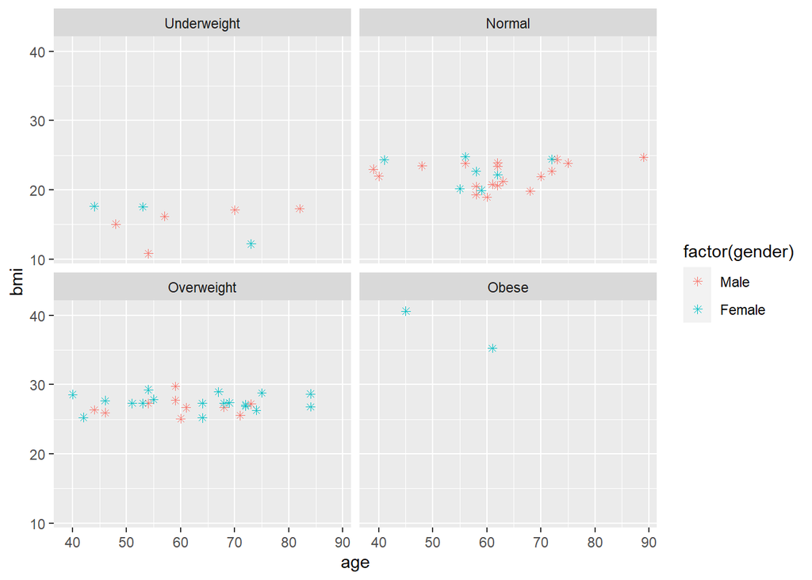

```r
ggplot(mantebea, aes(x=age, y=bmi, color=factor(gender))) +
  geom_point(shape = 8) +
  facet_wrap(~bmi_cat)
```

```r
## The chunk below has also been split into subgroups (faceting). A condition was however provided in this function, that is; people with patient_id number below 50. Hence, the False plot includes people with patient id above or greater than 50 whiles the True plot includes people with patient id below or less than 50. More people fell under the true plot from observation.
```

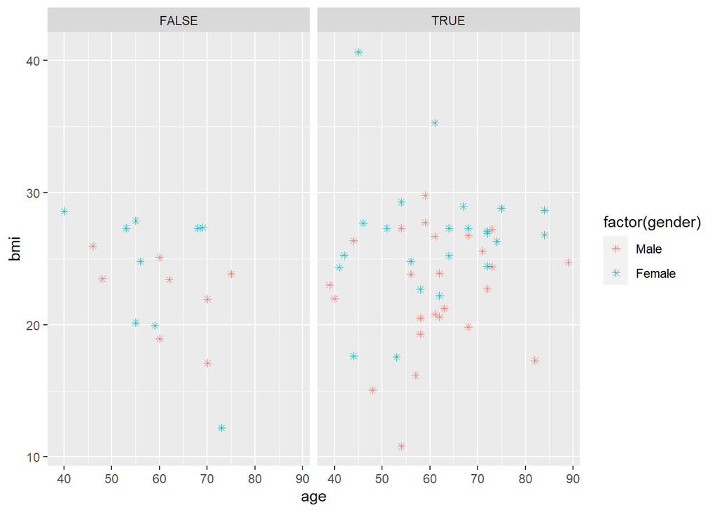

```r
ggplot(mantebea, aes(x=age, y=bmi, color=factor(gender))) +
  geom_point(shape = 8) +
  facet_wrap(~patient_id < 50)
```

```r
## For this next function, Im going to change the background theme of the plots above to give it a different look. This was just done for practice.
```

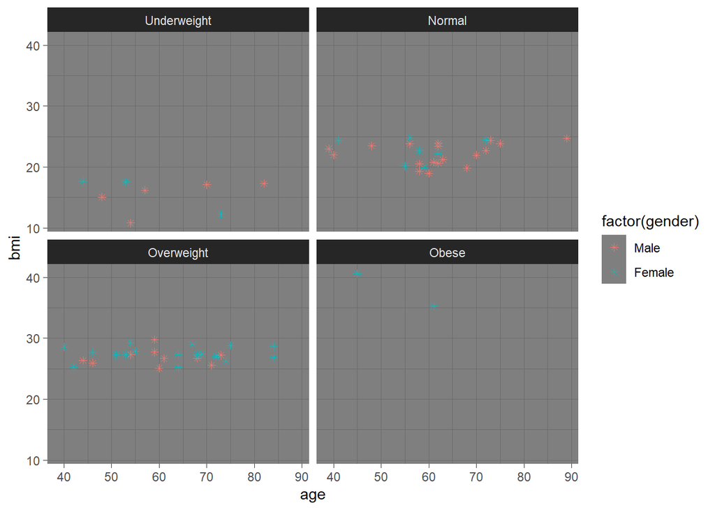

```r
ggplot(mantebea, aes(x=age, y=bmi, color=factor(gender))) +
  geom_point(shape = 8) +
  facet_wrap(~bmi_cat) +
  theme_dark()
```

```r
## I'm going to convert the plot from a scatter plot into a bubble plot in this next function by including a 'size' aesthetic. I will size the points by gender, therefore my color factor would change to exercise level. This is an attempt. Let's see how it goes.It should be noted that this is the first type of plot created today in an attempt to work on assignment given.
```

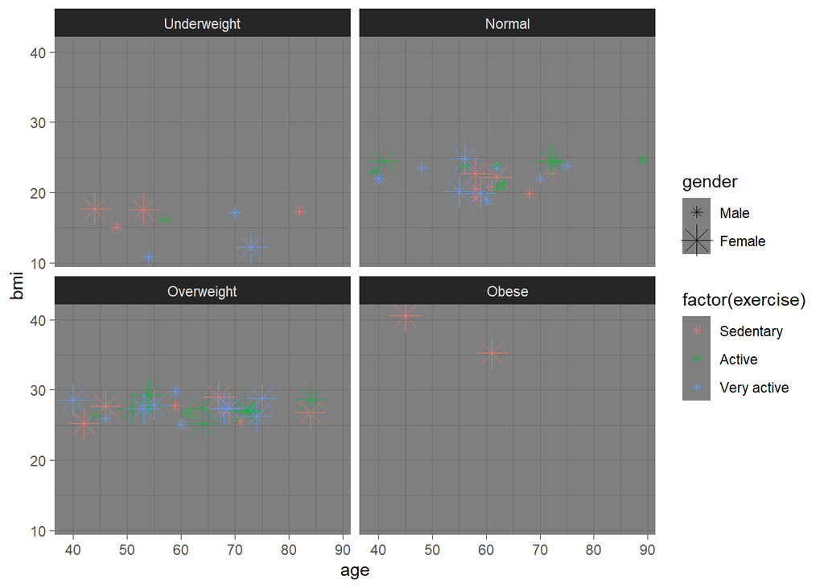

```r
ggplot(mantebea, aes(x=age, y=bmi, color=factor(exercise), size = gender)) +
  geom_point(shape = 8) +
  facet_wrap(~bmi_cat) +
  theme_dark()
```

```r
## The above function worked, however because of the shape of the points, we can't really see the bubbles. So I'm going to change the point shape in the next function. I believe the points are transparent and hollow enough so there will be no need to include the aesthetic "alpha".
```

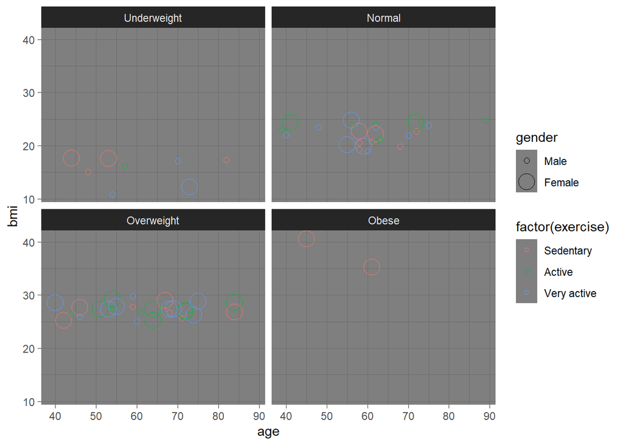

```r
ggplot(mantebea, aes(x=age, y=bmi, color=factor(exercise), size = gender)) +
  geom_point(shape = 1) +
  facet_wrap(~bmi_cat) +
  theme_dark()
```

```r
## For this next function, I'm going to create a line plot (second plot for the assignment) by including the 'group' aesthetic. I also changed the theme to a white background. So it didn't work the first time because each group (Patient id) consists of only one observation. I guess it's either i change the group or i remove the faceting. Let's try both and see. Okay, so removing the faceting didn't change anything. It still gave me the same problem. So let's change the group rathe. Eventually changing the group helped but then making the faceting variable the same as the color factor gave absolutely no problem.
```

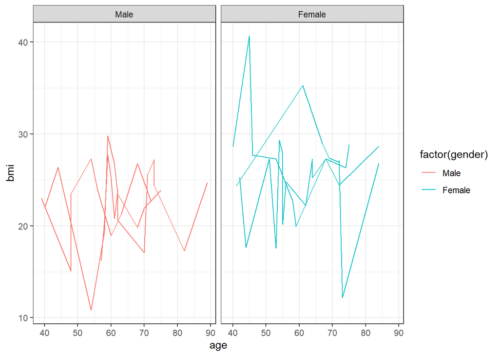

```r
ggplot(mantebea, aes(x=age, y=bmi, color=factor(gender), group = smoking)) +
  geom_line() +
  facet_wrap(~gender) +
  theme_bw()
```

```r
## I included this line plot below because I realized although I didn't meet any error, my plot wasn't actually a line plot, it had the zigzag look. However, I can't seem to understand why. Perhaps my honorable RD can throw more light on this for me once he goes through it. Thanks in advance.
```

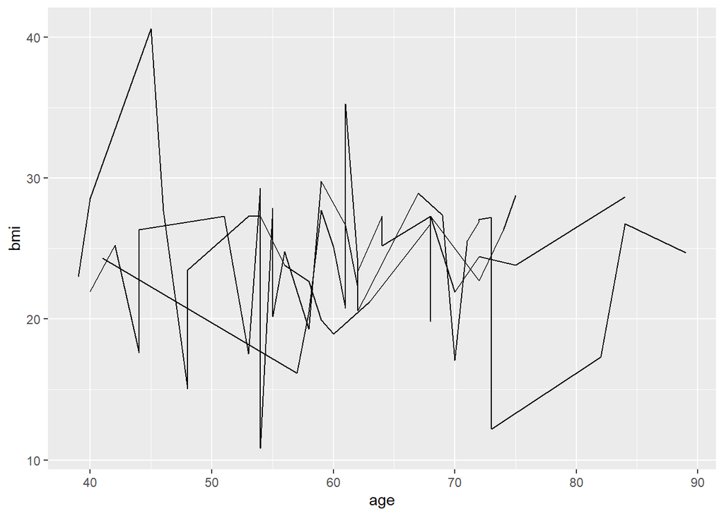

```r
ggplot(mantebea, aes(x=age, y=bmi, group = smoking)) +
  geom_line()
```

```r
## I'm making the same plot as above but a change in some variables used. This also worked. Line plotting was succesful.
```

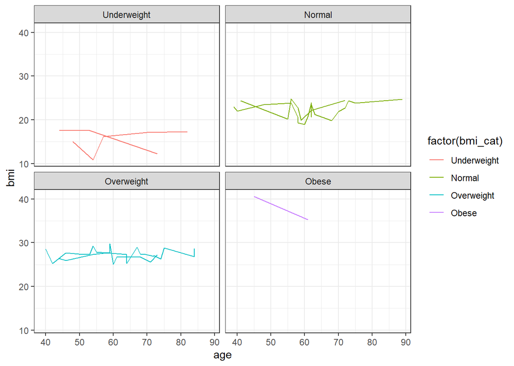

```r
ggplot(mantebea, aes(x=age, y=bmi, color=factor(bmi_cat), group = gender)) +
  geom_line() +
  facet_wrap(~bmi_cat) +
  theme_bw()
```

```r
## I'm plotting my third type of plot known as the bar plot. I will be using the geom_col function because I can provide both 'x' - categorical and 'y' - numerical variables. I tried two different 'x' variables : gender and bmi category. They both worked.
```

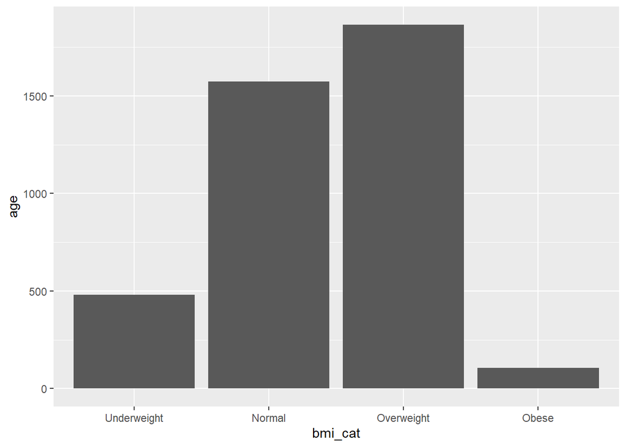

```r
ggplot(mantebea, aes(x=bmi_cat, y=age)) +
  geom_col()
```

```r
## I'm really enjoying this work so let me create my very last plot, a histogram and then I will  be done. This histogram is showing the distribution of age in the cancer dataset.
```

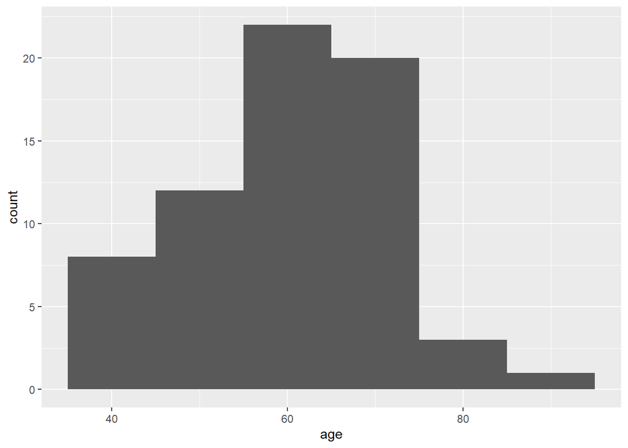

```r
ggplot(mantebea, aes(x= age)) +
  geom_histogram(binwidth = 10)
```

```r
?tbl_summary
```

```r
## The code chunk below provides a modified summary table of the cancer data set, based on the documentation provided on table summary. A similar version of the example 2 in the said documentation was used. I don't think i really understand everything I changed in this code but it still provided me with some results without any errors so I would go along with it. Hopefully I would get the hang of it after actual face to face discussion with my honorable RD. From the table, the mean age was 61 years with a standard deviation (SD), of 11.6,bmi had a mean of 24.2kg/m^2 and SD of 4.9. I'm guessing 'n' stands for frequency based on information in the said documentation. This will imply that there are 33 males and females each, giving the total of 66 patients. Also, 26 people have never smoked, 21 people are heavy smokers, 18 people are light smokers and the smoking status of 1 individual is unknown. The remaining categorical variables can be interpreted using this format. This brings me to the end of this assignment. Wow, roughly 3 hours have been spent on this work. Hope I did everythhing well my RD. I'm open to corrections, please be nice about it though. Haha, thanks and bye.
```

```r
mantebea %>%
  tbl_summary(
    by = NULL,
    label = NULL,
    statistic = list(all_continuous() ~ "{mean} ({sd})"),
    digits = list(age ~ c(0, 1)),
    sort = list (everything() ~ "frequency")
  )
```

| **Characteristic** | **N = 66**<sup>1</sup> |
| --- | --- |
| Patient ID | 34 (19) |
| Age | 61 (11.6) |
| Gender |  |
| Male | 33 (50%) |
| Female | 33 (50%) |
| BMI | 24.2 (4.9) |
| Smoking |  |
| Never smoked | 26 (40%) |
| Heavy smoker | 21 (32%) |
| Light smoker | 18 (28%) |
| Unknown | 1 |
| Exercise |  |
| Sedentary | 22 (33%) |
| Active | 22 (33%) |
| Very active | 22 (33%) |
| fruit |  |
| 0 | 24 (36%) |
| 1 | 24 (36%) |
| 2 | 12 (18%) |
| 3 | 5 (7.6%) |
| 4 | 1 (1.5%) |
| veg |  |
| 3 | 18 (27%) |
| 2 | 15 (23%) |
| 4 | 12 (18%) |
| 1 | 11 (17%) |
| 5 | 3 (4.5%) |
| 9 | 3 (4.5%) |
| 0 | 2 (3.0%) |
| 6 | 2 (3.0%) |
| Cancer | 51 (77%) |
| BMI Cat |  |
| Overweight | 30 (45%) |
| Normal | 26 (39%) |
| Underweight | 8 (12%) |
| Obese | 2 (3.0%) |

<sup>*1*</sup> Mean (SD); n (%)